# INFSCI 2595 Fall 2023 Homework: 05

Assigned September 27, 2023; Due: October 4, 2023

SOLUTION GUIDE

Submission time: October 4, 2023 at 11:00PM EST

#### Collaobrators

Include the names of your collaborators here.

## Overview

This assignment provides practice working with and manipulating Gaussian distributions. You will calculate derivatives, perform change-of-variable transformations, and also start working with the `optim()` function.

### IMPORTANT!!!

Certain code chunks are created for you. Each code chunk has `eval=FALSE` set in the chunk options. You **MUST** change it to be `eval=TRUE` in order for the code chunks to be evaluated when rendering the document.

You are free to add more code chunks if you would like.

## Load packages

You will use the `tidyverse` in this assignment, as you have done in the previous assignments.

```r
library(tidyverse)
```

## Problem 01

Consider a situation where a manufacturing company wants to get a better idea about the **mean** performance of a part they produce. Unfortunately, measuring the performance of that part requires a destructive experiment. Therefore, they would like to test as few parts as possible. Engineers within the company have performed experiments in the past, and so they hope that experience can help in some way.

To help out this company, we will assume that the part performance can be represented by a Gaussian likelihood, given the mean performance $\mu$ and the noise $\sigma$. We will assume the observation of each experiment, $x_{n}$, is conditionally independent given those hyperparameters. The joint distribution between $N$ observations can therefore be factored into the product of $N$ separate likelihoods:

$$p\left( \mathbf{x} \mid \mu, \sigma \right) = \prod_{n=1}^{N} \{
\mathrm{normal}\left(x_{n} \mid \mu, \sigma \right) \}$$

### 1a)

In order to perform a Bayesian analysis, we will need to specify our prior belief on the unknown parameters. The parameter the engineers are most concerned about is $\mu$. Let’s represent our prior belief on $\mu$ with a Gaussian prior parameterized by $\mu_{0}$ and $\tau_{0}$. After asking multiple engineers, it seems that the prior $\pm 2$ standard deviation interval or roughly 95% uncertainty interval around the prior mean, $\mu_{0}$ is between 115 units and 135 units.

**Based on the interval suggested by the engineers, solve for the $\mu_{0}$ and $\tau_{0}$ hyperparameters for the Gaussian prior on the mean, $\mu$.**

#### SOLUTION

The statement that $\pm2$ prior standard deviations is between 115 and 135 can be written as:

$$115 = \mu_{0} - 2 \tau_{0} \\
135 = \mu_{0} + 2 \tau_{0}$$

$$\mu_{0} = 115 + 2 \tau_{0}$$

Substitute the above equality into the second expression within the first equation block:

$$135 = \left( 115 + 2 \tau_{0} \right) + 2\tau_0 = 115 + 4 \tau_{0}$$

Which allows solving for $\tau_{0}$:

$$135 - 115 = 4 \tau_0 \\
20 = 4 \tau_0 \\
\tau_0 = \frac{20}{4} \\
\tau_0 = 5$$

Substituting $\tau_0$ back into the expresion for $\mu_0$ gives:

$$\mu_0 = 115 + 2 \times \tau_0 = 115 + 2 \times 5 = 115 + 10 \\
\mu_0 = 125$$

Thus, the hyperprior on $\mu$ is a Gaussian with prior mean $\mu_0 = 125$ and prior standard deviation $\tau_0 = 5$. Note that, if you wanted to be exact and use the middle 95% uncertainty interval is $\pm 1.96$ standard deviations around the mean your final numbers would be slightly different.

### 1b)

Let’s examine the prior uncertainty another way besides the 95% prior uncertainty interval.

**Based on your result in Problem 1a), calculate the 25th and 75th quantiles associated with the prior Gaussian on $\mu$. The interval between these two quantiles contains what fraction of the probabilty mass?**

#### SOLUTION

The 25th and 75th quantiles can be easily calculated using the `qnorm()` function.

```r
qnorm(p = 0.25, mean = 125, sd = 5)
```

```
## [1] 121.6276
```

```r
qnorm(p = 0.75, mean = 125, sd = 5)
```

```
## [1] 128.3724
```

50% of the probability mass is contained between the 25th and 75th quantiles. Thus, if we generated thousands of random draws from the distribution, we can expect 50% of the observations to be between these two values.

### 1c)

Besides wanting to produce parts with as high as performance as possible, the manufacturing company has several customer requirements they must satisfy. One of their customers has stated they are concerned if large numbers of parts would have performance values of 117 units or less.

**Calculate the prior probability that the mean performance, $\mu$ is less than 117, based on your solution to Problem 1a).**

#### SOLUTION

We can use the CDF to answer this question. We do not have to code the Gaussian CDF ourselves, instead we can use the `pnorm()` function to calculate the probability that $\mu$ is less than 117.

```r
pnorm(117, mean = 125, sd = 5)
```

```
## [1] 0.05479929
```

As we can see above, there is about a 5.5% chance a-priori that the average performance will be less than 117.

### 1d)

Most of the engineers feel confident that the process standard deviation, $\sigma$, is known. They believe that $\sigma = 5$ units. We will now use this value of $\sigma$ to estimate the required number of observations to achieve a target posterior standard deviation on the mean performance, $\mu$.

**Based on $\sigma = 5$ and your result in Problem 1a), how many observations are required to have a posterior standard deviation on $\mu$ to be $\tau_{N} = 2$? How many observations are required to have $\tau_{N} = 0.5$?**

**You should write out the expression for the number of required observations to achieve this goal and then calculate the values associated with two different $\tau_{N}$ values.**

#### SOLUTION

We need to use the expression for the **posterior precision** discussed in lecture. The posterior precision for the normal likelihood with a conjugate normal prior and known standard deviation is the sum of the prior precision and the data precision:

$$\frac{1}{\tau_{N}^{2}} = \frac{1}{\tau_{0}^2} + \frac{N}{\sigma^2}$$

We can rearrange the above expression to solve for $N$ in terms of the known $\sigma$, the assumed $\tau_0$ and the desired $\tau_N$:

$$N = \sigma^2 \times \left(\frac{1}{\tau_{N}^{2}} -
\frac{1}{\tau_{0}^{2}} \right)$$

We can now easily calculate the required number of observations to achieve the target posterior precision of 2:

```r
5^2 * ((1/2^2) - (1/5^2))
```

```
## [1] 5.25
```

Thus, we would need 6 fully tested parts (since we can’t test a fraction of a part) to get the posterior standard deviation less than 2 units.

If we instead wanted the target posterior standard deviation to be 0.5 units:

```r
5^2 * ((1/0.5^2) - (1/5^2))
```

```
## [1] 99
```

We would need to test 99 parts! The simple formula for the posterior precision allowed us to get a sense about the relationship of sample size and target levels of precision.

### 1e)

A small contingent of engineers feel that the others are being overly optimistic. This group of engineers feel that the process standard deviation is $\sigma = 15$ units, and they do not feel comfortable specifying such a tight prior on $\mu$. They are worried that a large number of tests will be needed to achieve $\tau_{N} = 3$ units.

**Based on this small group of engineers, estimate the number of observations required to achieve $\tau_{N} = 3$ assuming $\sigma = 15$ and an infinitely diffuse prior with $\tau_{0} \rightarrow \infty$.**

**You should first write out the expression for the number of required observations and then calculate the value.**

#### SOLUTION

In the limit that $\tau_0 \rightarrow \infty$, the posterior precision converges to:

$$\frac{1}{\tau_{N}^{2}} \rightarrow \frac{N}{\sigma^2}$$

Under these assumptions, it is easy to solve for the required number of samples to acheive a target posterior precision:

$$N \approx \frac{\sigma^2}{\tau_{N}^{2}}$$

Let’s now substitute in the values from the problem statement:

```r
15^2 / 3^2
```

```
## [1] 25
```

Thus, we would need 25 experiments to achieve a posterior standard deviation of 3 units, if this small group of engineers are correct.

## Problem 02

In lecture, we introduced the normal-normal model with an unknown mean, $\mu$, and known standard deviation, $\sigma$. Although we discussed the interpretation of the posterior distribution when using the conjugate normal prior on $\mu$, we did not fully derive the posterior. In this problem, you will get practice working with Gaussians by deriving the expression for the *posterior mode* or Max A-Posteriori (MAP) estimate. You do **not** need to *complete the square* to solve this problem. Instead, you will find the MAP by optimizing the un-normalized log-posterior with respect to $\mu$. The recording and notes provided on Canvas which show how to derive the Maximum Likelihood Estimate (MLE) may be helpful with this problem.

This problem uses the same nomenclature as lecture. The prior on $\mu$ is a Gaussian with prior mean $\mu_{0}$ and prior standard deviation $\tau_{0}$.

### 2a)

The posterior on $\mu$ given $N$ observations $\mathbf{x}$ and known standard deviation $\sigma$ is proportional to:

$$p\left(\mu \mid \mathbf{x}, \sigma\right) \propto \prod_{n=1}^{N} \left(
\mathrm{normal} \left( x_n \mid \mu, \sigma \right) \right) \times
\mathrm{normal}\left( \mu \mid \mu_0, \tau_0\right)$$

The denominator in Bayes’ rule is ignored in the above expression. Because of that I will typically refer to the expression above as the *un-normalized* posterior.

**Write out the expression for the un-normalized log-posterior on $\mu$. You may drop all terms that do not involve $\mu$. You should show several steps and not simply write down the final answer.**

#### SOLUTION

Let’s start out by considering the log-likelihood associated with the $n$-th observation:

$$\log \left( \mathrm{normal}\left(x_n \mid \mu, \sigma \right) \right) =
-\frac{1}{2} \log \left(2\pi\right) - \frac{1}{2}
\log\left(\sigma^2\right) - \frac{1}{2\sigma^2} \left(x_n - \mu\right)^2$$

And then let’s drop all terms that do not involve $\mu$:

$$\log \left( \mathrm{normal}\left(x_n \mid \mu, \sigma \right) \right)
\propto - \frac{1}{2\sigma^2} \left(x_n - \mu\right)^2$$

We then sum over the $N$ observations to get the log-likelihood up to a normalizing constant:

$$\log \left(p\left( \mathbf{x} \mid \mu, \sigma \right) \right) \propto
-\frac{1}{2\sigma^2} \sum_{n=1}^{N} \left( \left(x_n - \mu\right)^2
\right)$$

We start out similarly with the log-prior:

$$\log\left( \mathrm{normal} \left( \mu \mid \mu_0, \tau_0 \right) \right)
= -\frac{1}{2} \log \left(2\pi\right) - \frac{1}{2}
\log\left(\tau_0^2\right) - \frac{1}{2\tau_0^2} \left(\mu -
\mu_0\right)^2$$

Drop all terms that do not involve $\mu$ to yield the log-prior up to a normalizing constant:

$$\log\left( \mathrm{normal} \left( \mu \mid \mu_0, \tau_0 \right) \right)
\propto- \frac{1}{2\tau_0^2} \left(\mu - \mu_0\right)^2$$

Sum the log-likelihood with the log-prior to yield the log-posterior up to a normalizing constant:

$$\log \left( p\left( \mu \mid \mathbf{x}, \sigma \right) \right) \propto
-\frac{1}{2\sigma^2} \sum_{n=1}^{N} \left( \left( x_n - \mu \right)^2
\right) - \frac{1}{2\tau_{0}^2} \left( \mu - \mu_0 \right)^2$$

### 2b)

**Derive the derivative of the un-normalized log-posterior with respect to $\mu$. Your final answer should be written in terms of the sufficient statistic, the sample average $\bar{x}$.**

#### SOLUTION

Differentiation is a linear operator, thus we can apply the derivative within the summation series:

$$\frac{d}{d\mu} \left( \log \left( p\left( \mu \mid \mathbf{x}, \sigma
\right) \right) \right) = -\frac{1}{2\sigma^2} \sum_{n=1}^{N} \left(
\frac{d}{d\mu}\left( \left( x_n - \mu \right)^2 \right) \right) -
\frac{1}{2\tau_{0}^2} \frac{d}{d\mu}\left( \left( \mu - \mu_0 \right)^2
\right)$$

Written this way, we see that we only need to calculate two derivatives, the first is the $n$-th observation’s contribution within the summation series, and the second is associated with the log-prior. Both have similar functional forms in that they are quadratic (due to the Gaussian likelihood and Gaussian prior), but the “position” of the unknown is different between the two. Thus, the signs of the result should be different.

Let’s start with the term associated with the likelihood:

$$\frac{d}{d\mu} \left( \left(x_n - \mu\right)^2 \right) = -2 \times
\left(x_n - \mu \right)$$

And likewise for the log-prior term:

$$\frac{d}{d\mu} \left( \left(\mu - \mu_0\right)^2 \right) = 2 \times
\left(\mu - \mu_0 \right)$$

Placing those terms back into the original expression involving the summation and the other coefficients, the derivative can be written as:

$$\frac{d}{d\mu} \left( \log \left( p\left( \mu \mid \mathbf{x}, \sigma
\right) \right) \right) = -\frac{1}{2\sigma^2} \sum_{n=1}^{N} \left( -2
\times \left(x_n - \mu \right) \right) - \frac{1}{2\tau_{0}^2} \times
2 \times \left(\mu - \mu_0 \right)$$

Simplify:

$$\frac{d}{d\mu} \left( \log \left( p\left( \mu \mid \mathbf{x}, \sigma
\right) \right) \right) = \frac{1}{\sigma^2} \sum_{n=1}^{N}
\left(\left(x_n - \mu \right) \right) - \frac{1}{\tau_{0}^2} \left(\mu
- \mu_0 \right)$$

The summation series can be simplified by “distributing” the summation over the individual terms:

$$\sum_{n=1}^{N} \left(\left(x_n - \mu \right) \right) = \sum_{n=1}^{N}
\left(x_n\right) - \sum_{n=1}^{N} \left(\mu\right)$$

The second term on the right hand side is simply a summation of a constant, $\mu$, and thus simplifies to:

$$\sum_{n=1}^{N} \left(\mu\right) = N \times \mu$$

The summation of the $N$ observations can be simplified by using the sample average, which is defined as:

$$\bar{x} = \frac{1}{N} \sum_{n=1}^{N} \left(x_n\right)$$

Thus, the summation series is the sample average multiplied by the number of observations:

$$\sum_{n=1}^{N} \left(x_n\right) = N \times \bar{x}$$

These quantities can be placed back in the expression for the derivative:

$$\frac{d}{d\mu} \left( \log \left( p\left( \mu \mid \mathbf{x}, \sigma
\right) \right) \right) = \frac{1}{\sigma^2} \left( N\bar{x} - N \mu
\right) - \frac{1}{\tau_{0}^2} \left(\mu - \mu_0 \right)$$

Which simplifies to the final result:

$$\frac{d}{d\mu} \left( \log \left( p\left( \mu \mid \mathbf{x}, \sigma
\right) \right) \right) = \frac{N}{\sigma^2} \left( \bar{x} - \mu
\right) - \frac{1}{\tau_{0}^2} \left(\mu - \mu_0 \right)$$

### 2c)

**Determine the posterior mode or MAP by setting the derivative expression you determined in Problem 2b) to 0. Denote the posterior mode on $\mu$ as $\mu_{MAP}$.**

#### SOLUTION

The posterior mode is found by setting the first derivative to 0 and solving for $\mu$:

$$\frac{d}{d\mu} \left. \left( \log \left( p\left( \mu \mid \mathbf{x},
\sigma \right) \right) \right) \right|_{\mu_{MAP}} = 0 =
\frac{N}{\sigma^2} \left( \bar{x} - \mu_{MAP} \right) -
\frac{1}{\tau_{0}^2} \left(\mu_{MAP} - \mu_0 \right)$$

Rearrange the right hand side by grouping the terms that involve $\mu_{MAP}$:

$$\frac{N}{\sigma^2} \left( \bar{x} - \mu_{MAP} \right) -
\frac{1}{\tau_{0}^2} \left(\mu_{MAP} - \mu_0 \right) =
\frac{N}{\sigma^2} \bar{x} + \frac{1}{\tau_0^2}\mu_0 - \left(
\frac{N}{\sigma^2} + \frac{1}{\tau_0^2} \right) \mu_{MAP} = 0$$

Rearrange by moving the term associated with the parantheses to the other side.

$$\frac{N}{\sigma^2} \bar{x} + \frac{1}{\tau_0^2}\mu_0 = \left(
\frac{N}{\sigma^2} + \frac{1}{\tau_0^2} \right) \mu_{MAP}$$

The posterior mode is therefore:

$$\mu_{MAP} = \frac{ \frac{N}{\sigma^2} \bar{x} + \frac{1}{\tau_0^2}
\mu_0} {\frac{N}{\sigma^2} + \frac{1}{\tau_0^2}}$$

### 2d)

Your expression for the posterior mode should look familiar. In fact, we worked with the expression for the MAP in lecture, but we referred to that expression by a different name.

**Your answer in Problem 2c) should be equivalent to an expression provided in lecture. Which expression is it the same as? Why is your result for the posterior mode the same as that expression? Think in terms of the type of distribution we know the posterior to be given the problem formulation.**

#### SOLUTION

The posterior mode or MAP expression we derived in Problem 2c) is identical to the expression we discussed for the posterior mean, $\mu_{N}$, in lecture. The two expressions are the same because we used a conjugate Normal prior on the unknown mean, $\mu$, with our Normal likelihood. The normal is conjugate to the normal, and thus the posterior distribution is also a Gaussian! The mode of a Gaussian is equal to its mean (and also its median). That is why $\mu_{MAP} = \mu_{N}$!

## Problem 03

In lecture, we discussed learning an unknown mean of a normal likelihood, given a series of observations. We compared the MLE to the Bayesian result with a conjugate normal prior, assuming the measurement standard deviation (the likelihood noise) was known. We qualitatively and graphically discussed the more complicated situation of an unknown mean and unknown noise. We will continue that discussion in our next lecture, where we will see how to approximate the joint posterior with the Laplace Approximation.

As a stepping stone to the two unknown parameter model, you will work with a normal likelihood but switching which parameters are known and unknown. Thus, you will work with a normal likelihood with a *known* mean, $\mu$, while the standard deviation, $\sigma$, is unknown. The $N$ observations (or measurements) are still denoted as a vector, $\mathbf{x}$.

The posterior distribution on the unknown $\sigma$ given the observations, $\mathbf{x}$, and the known mean, $\mu$, is proportional to:

$$p \left(\sigma \mid \mathbf{x}, \mu\right) \propto p\left(\mathbf{x}
\mid \mu, \sigma \right) p\left(\sigma\right)$$

We will continue to assume all observations are conditionally independent given the parameters. The likelihood therefore factors into the product of $N$ normal likelihoods. Thus, the posterior is proportional to:

$$p \left(\sigma \mid \mathbf{x}, \mu\right) \propto \prod_{n=1}^{N}
\left(\mathrm{normal}\left( x_n \mid \mu, \sigma \right) \right)
\times p\left(\sigma\right)$$

Notice that the prior distribution must be placed on $\sigma$. The example discussed in lecture used a Uniform distribution as the prior on $\sigma$. However, in this assignment you will work with a different distribution, one that we will work with more when we start fitting regression models. You will use an **Exponential distribution** as the prior on $\sigma$. The shorthand notation for the Exponential distribution is usually $\mathrm{Exp}$, and I will always use a capital E to denote the distribution and not the exponential function $\exp()$. The Exponential distribution has a single hyperparameter, known as the rate parameter and is sometimes denoted as $\lambda$. The Exponential probability density function with rate $\lambda$ is:

$$\mathrm{Exp}\left(\sigma \mid \lambda\right) = \lambda \exp
\left(-\lambda \sigma \right)$$

The un-normalized posterior on the unknown likelihood noise, $\sigma$, is therefore:

$$p \left(\sigma \mid \mathbf{x}, \mu\right) \propto \prod_{n=1}^{N}
\left(\mathrm{normal}\left( x_n \mid \mu, \sigma \right) \right)
\times \mathrm{Exp}\left( \sigma \mid \lambda \right)$$

### 3a)

You will now start working with the un-normalized log-posterior for unknown $\sigma$.

**You must derive the expression for the un-normalized log-posterior on $\sigma$. You may drop the constant terms and terms that do not directly involve $\sigma$. You do not need to simplify the quadratic portion within the likelihood.**

#### SOLUTION

Start by plugging in the expression for the normal likelihood for each observation and the Exponential density.

$$p \left(\sigma \mid \mathbf{x}, \mu \right) \propto \prod_{n=1}^{N}
\left(\frac{1}{\sqrt{2\pi\sigma^2}} \exp\left( -\frac{1}{2\sigma^2}
\left(x_n - \mu\right)^2 \right) \right) \times \lambda \exp
\left(-\lambda \sigma \right)$$

Apply the natural log:

$$\log \left( p \left(\sigma \mid \mathbf{x}, \mu \right) \right) \propto
\sum_{n=1}^{N} \left( -\frac{1}{2} \log\left(2\pi \right) -\frac{1}{2}
\log\left(\sigma^2 \right) -\frac{1}{2\sigma^2} \left(x_n - \mu
\right)^2 \right) + \log\left(\lambda\right) -\lambda \sigma$$

Expand the summation through the times in the likelihood:

$$\log \left( p \left(\sigma \mid \mathbf{x}, \mu \right) \right) \propto
\sum_{n=1}^{N}\left(-\frac{1}{2} \log\left(2\pi\right)\right) +
\sum_{n=1}^{N} \left( -\frac{1}{2} \log \left(\sigma^2\right)\right)
-\frac{1}{2\sigma^2}\sum_{n=1}^{N} \left( \left(x_n - \mu \right)^2
\right) + \log\left(\lambda\right) -\lambda\sigma$$

Drop the terms that are not associated with the unknown $\sigma$:

$$\log \left( p \left(\sigma \mid \mathbf{x}, \mu \right) \right) \propto
-\frac{N}{2} \log \left( \sigma^2 \right)
-\frac{1}{2\sigma^2}\sum_{n=1}^{N} \left( \left(x_n - \mu \right)^2
\right) -\lambda\sigma$$

### 3b)

When we discussed the normal-normal model for the unknown mean, we talked about the sufficient statistic being the sample average. In this situation, an unknown standard deviation with a known mean, we also have a sufficient statistic, but it is not the sample average. The sufficient statistic is defined for you in the equation block below:

$$v = \frac{1}{N} \sum_{n=1}^{N}\left( \left(x_n - \mu\right)^2 \right)$$

**Simplify your result from Problem 3a) by making use of the sufficient statistic, $v$. Why do you think the quantity $v$ is referred to as being “sufficient”? Does your expression for the un-normalized log-posterior depend on the individual observations after making use of $v$?**

#### SOLUTION

The expression for the log-posterior greatly simplifies when we make use of the sufficient statistic. To see how, let’s rewrite the sufficient statistic expression as:

$$Nv = \sum_{n=1}^{N}\left( \left(x_n - \mu\right)^2 \right)$$

We can now see that the summation series term is equal to the product of the number of observations, $N$, and the sufficient statistic, $v$. Let’s substitute the above expression into the expression for log-posterior on $\sigma$:

$$\log \left( p\left( \sigma \mid \mathbf{x}, \mu \right) \right) \propto
-\frac{N}{2} \log \left( \sigma^2\right) - \frac{Nv}{2\sigma^2} -
\lambda \sigma$$

“Sufficient” represents that all information content from the data is contained within that single value. The log-posterior does not require the individual observations. We simply need to know the quantity $v$.

### 3c)

Let’s see how the un-normalized log-posterior behaves under a particular set of assumptions. The code chunk below defines a sample size of $N = 21$ and a sufficient statistic $v = 4.2$.

```r
N <- 21
v <- 4.2
```

In this problem, you will define a function `log_post_sigma_unnorm()` which has as input arguments, `sigma`, `N`, `v`, and `lambda`. The argument `sigma` is the $\sigma$ value, `N` is the sample size, `v` is the sufficient statistic, and `lambda` is the prior rate parameter, $\lambda$.

**Define the `log_post_sigma_unnorm()` function using the arguments and order of the arguments given in the problem statement.**

#### SOLUTION

```r
### set input arguments !!!
log_post_sigma_unnorm <- function(sigma, N, v, lambda)
{
  -N * log(sigma) - 0.5*(N*v)/sigma^2 - lambda * sigma
}
```

### 3d)

Let’s visualize the log-posterior with respect to $\sigma$. You will use the assigned `N` and `v` variables, and assume that the prior rate parameter is equal to 0.75, $\lambda=0.75$.

**Complete the code chunk below. Assign a vector of 101 evenly spaced values between 0.5 and 4.5 to the variable `sigma` within the `tibble`. Pipe the result to a `mutate()` call and calculate the log-posterior using the `log_post_sigma_unnorm()` function. The log-posterior should be saved to the variable `log_post`. Pipe the result to `ggplot()` and plot the `sigma` and `log_post` variables as the `x` and `y` aesthetics, respectively. Use a `geom_line()` geometric object.**

**Does the log-posterior have one or several modes? Does the shape of the log-posterior look like a parabola?**

#### SOLUTION

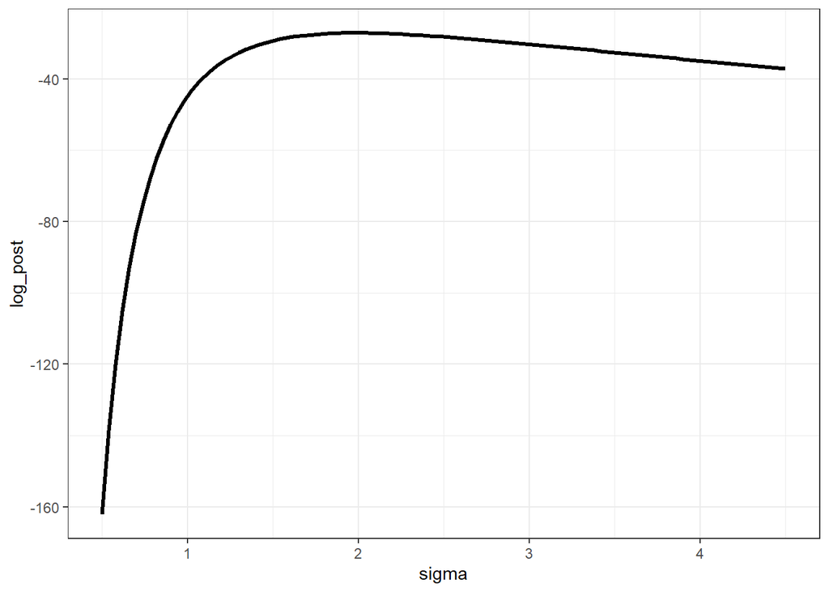

```r
tibble::tibble(
  sigma = seq(0.5, 4.5, length.out = 101)
) %>%
  mutate(log_post = log_post_sigma_unnorm(sigma, N = N, v = v, lambda = 0.75)) %>%
  ggplot(mapping = aes(x = sigma, y = log_post)) +
  geom_line(linewidth = 1.15) +
  theme_bw()
```

The log-posterior is unimodal, but the shape does not look parabolic. The side after the mode drops off slowly compared to the left hand side before the mode. A parabola does not behave in that way.

### 3e)

Next week in lecture, we will work with the quadratic or Laplace Approximation to approximate the posterior distribution as a Multivariate Normal. Although this can be a useful approximation, it is not appropriate for this type of situation. The likelihood noise, $\sigma$, has a natural lower bound of 0. A Gaussian distribution has no such constraints, and so allows all values from negative infinity to positive infinity! Therefore, even though the prior Exponential distribution respects the bound on $\sigma$, if we would use the Laplace Approximation to approximate the posterior, the lower bound would be violated!

We need to make use of a transformation in order to overcome this limitation. Since the likelihood noise is lower bounded at 0, we will apply a log-transformation. The transformed variable, $\varphi$, will be equal to the log of $\sigma$. Thus, the transformation or **link** function, $g\left(\right)$, is equal to the log function:

$$\varphi = g\left(\sigma\right) = \log \left(\sigma\right)$$

The change-of-variables formula, written in terms of the log-density, is given below:

$$\log\left(p_{\varphi} \left(\varphi \mid \mathbf{x}, \mu\right) \right)
= \log \left( p_{\sigma} \left( g^{-1} \left(\varphi \right) \mid
\mathbf{x}, \mu \right) \right) + \log \left( \left| \frac{d}{d\varphi}
\left( g^{-1}\left(\varphi\right) \right) \right| \right)$$

This may seem like an intimidating expression, but it simply says plug in the expression for $\sigma$ in terms of $\varphi$ (the inverse of the link function) into the log-posterior expression on $\sigma$. Then add in the log of the derivative of the inverse link function with respect to $\varphi$. The recording and notes provided on Canvas about performing change-of-variables with the simple linear z-score transformation can help with further discussion and practice working with the change-of-variables procedure.

Let’s tackle this problem by first determining the log of the derivative of the inverse link function.

**The link function is the log. What is the inverse link function? Write down the expression for calculating $\sigma$ as a function of $\varphi$. Then calculate the derivative of the inverse link function with respect to $\varphi$. Finally, write down the log of the derivative of the inverse link function.**

#### SOLUTION

The inverse link function is the inverse of the log, which is the exponential. Thus, the inverse link function is:

$$\sigma = g^{-1}\left( \varphi \right) = \exp \left( \varphi \right)$$

The derivative of the inverse link function is simply the derivative of the exponential of $\varphi$ with respect $\varphi$. The derivative is therefore simply equal to function itself!

$$\frac{d}{d\varphi} \left( \exp \left( \varphi \right) \right) = \exp
\left( \varphi \right)$$

The exponential of a quantity is always a positive number, so the absolute value equals the exponential.

The log is the inverse operation of the exponential function, and so the log of the derivative is simply the $\varphi$!

$$\log \left( \exp \left(\varphi \right) \right) = \varphi$$

Thus, the complicated looking log-derivative is simply just $\varphi$!

$$\log \left( \left| \frac{d}{d\varphi} \left( g^{-1}\left(\varphi\right)
\right) \right| \right) = \varphi$$

### 3f)

To handle the substitution portion, you will define a new function `log_post_varphi_unnorm()` which accepts as input arguments, `varphi`, `N`, `v`, and `lambda`. The last three arguments are identical to those in `log_post_sigma_unnorm()`, while the first argument is the value of the transformed variable $\varphi$. Within the function, you must calculate `sigma` based on the supplied value of `varphi` using the correct inverse link function. With the value of `sigma` calculated, you can evaluate the log-posterior just as you did in previously. You must then account for the log-derivative adjustment by correctly adding in the log of the derivative you calculated in Problem 3e).

**Complete the code chunk below by calculating the quantities specified in the comments.**

#### SOLUTION

```r
### set the input arguments !!!
log_post_varphi_unnorm <- function(varphi, N, v, lambda)
{
  # back-calculate sigma given varphi
  sigma <- exp( varphi )

  # calculate the unnormalized log-posterior on sigma
  log_post <- log_post_sigma_unnorm(sigma, N, v, lambda)

  # account for the derivative adjustment
  log_post + varphi
}
```

### 3g)

Now visualize the un-normalized log-posterior on the transformed variable $\varphi$. The code chunk below is similar to that used Problem 3d), except now you must define a vector of $\varphi$ values instead of $\sigma$ values. In Problem 3d), you calculated an evenly spaced vector of points between 0.5 and 4.5, in the $\sigma$ space. Transform those bounds to the appropriate values in $\varphi$ space and define a vector of 101 evenly spaced points between the transformed bounds. Pipe the result into `mutate()` and calculate the un-normalized log-posterior using the `log_post_varphi_unnorm()` function and save the result to the `log_post` variable. Pipe the result into `ggplot()` and visualize `varphi` and `log_post` as the `x` and `y` aesthetics with a `geom_line()`.

You will continue to use a prior rate parameter value of 0.75, $\lambda = 0.75$.

**Visualize the un-normalized log-posterior on the transformed $\varphi$ variable, following the instructions in the problem statement. Does the log-posterior appear more parabolic now?**

#### SOLUTION

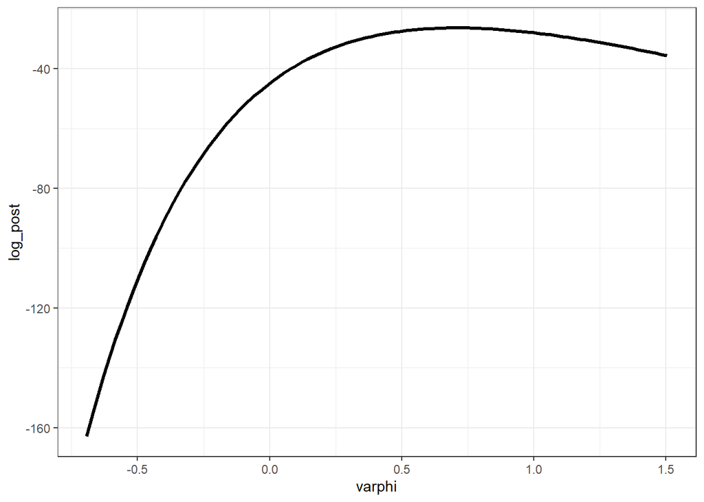

```r
tibble::tibble(
  varphi = seq(log(0.5), log(4.5), length.out = 101)
) %>%
  mutate(log_post = log_post_varphi_unnorm(varphi, N = N, v = v, lambda = 0.75)) %>%
  ggplot(mapping = aes(x = varphi, y = log_post)) +
  geom_line(linewidth = 1.15) +
  theme_bw()
```

Although not perfectly parabolic, the behavior around the mode does seem to be more in line with a parabola compared to the un-normalized log-posterior in the original $\sigma$ space.

## Problem 04

As you have seen in both lecture and the homework assignments, we will work with optimizing likelihoods and posteriors a lot in this course. Although we will work through the derivations for most problems, you will be allowed to use existing general purpose optimization packages to perform the optimization. This problem introduces you to the `optim()` function so that you may get used to its arguments and syntax.

### 4a)

You will use `optim()` to find the value of `x` which maximizes the function `sin(x)` over the interval $-5\pi/8$ to $9\pi/8$. First, plot the `sin()` function over this interval. There are multiple ways to accomplish plotting a function within `ggplot2`, the method outlined below is a simple approach to get you further practice working with basic `ggplot2` commands.

**Use the `seq()` function to create a vector `x` within the `tibble` started in the code chunk below. Set the arguments to `seq()` such that the vector contains 1001 elements from $-5\pi/8$ to $9\pi/8$. Pipe the `tibble` into `ggplot()` and plot the `sin(x)` with `geom_line()`.**

#### SOLUTION

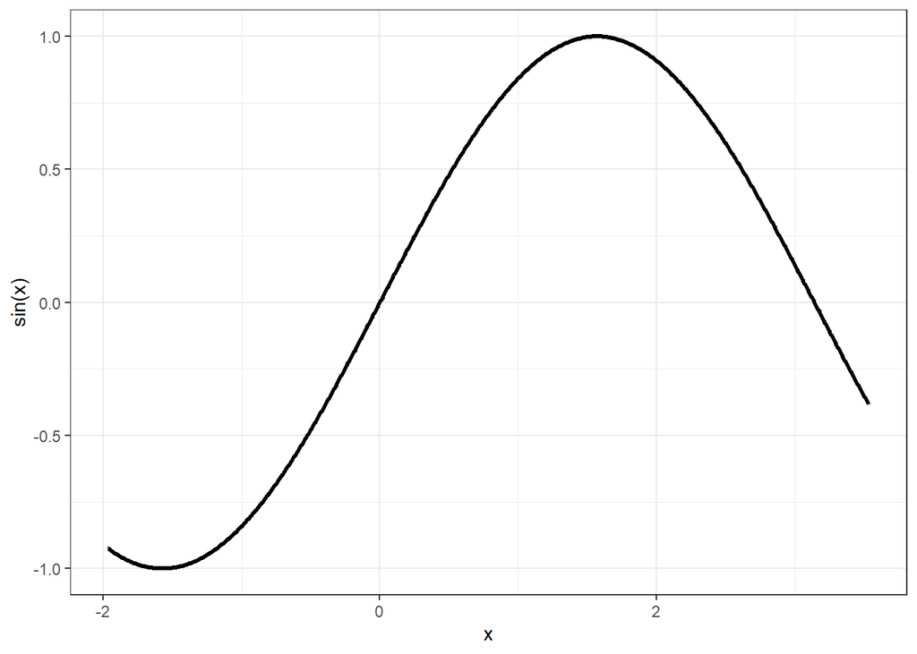

```r
tibble::tibble(
  x = seq(-5*pi/8, 9*pi/8, length.out = 1001)
) %>%
  ggplot(mapping = aes(x = x, y = sin(x))) +
  geom_line(linewidth = 1.15) +
  theme_bw()
```

### 4b)

Let’s now optimize the function with `optim()`. Type `?optim` into the R console to bring up the help documentation for the function. The documentation describes the arguments we need to pass into the function. The `par` argument is the first argument to `optim()` and is the initial guess. The second argument, `fn`, is the function we wish to optimize.

**Use `optim()` to find the `x` value which maximizes `sin()` within the interval of interest. Set the initial guess to 0. Set the `method` in `optim()` to be `"Brent"` and set the `hessian` argument equal to `TRUE`. Set the `lower` and `upper` arguments in the `optim()` to be `-5*pi/8` and `9*pi/8`, respectively. Store the result to `opt_sine_01` and print the result to the screen. Which `control` argument in `optim()` tells `optim()` to maximize instead of minimize? We will not pass in a gradient function, what should `gr` be set to?**

#### SOLUTION

```r
opt_sine_01 <- optim(0,
                     sin,
                     gr = NULL,
                     method = "Brent",
                     lower = -5*pi/8, upper = 9*pi/8,
                     hessian = TRUE,
                     control = list( fnscale=-1 ))

opt_sine_01
```

```
## $par
## [1] 1.570796
##
## $value
## [1] 1
##
## $counts
## function gradient
##       NA       NA
##
## $convergence
## [1] 0
##
## $message
## NULL
##
## $hessian
##            [,1]
## [1,] -0.9999997
```

### 4c)

**Reperform the `optim()` call from Problem 3b), but this time with an initial guess of 3 instead of 0. Store the result to `opt_sine_02`. Print `opt_sine_02` to the screen.**

```r
opt_sine_02 <- optim(3,
                     sin,
                     gr = NULL,
                     method = "Brent",
                     lower = -5*pi/8, upper = 9*pi/8,
                     hessian = TRUE,
                     control = list( fnscale=-1 ))

opt_sine_02
```

```
## $par
## [1] 1.570796
##
## $value
## [1] 1
##
## $counts
## function gradient
##       NA       NA
##
## $convergence
## [1] 0
##
## $message
## NULL
##
## $hessian
##            [,1]
## [1,] -0.9999997
```

### 4d)

We will now practice passing in extra arguments to the function we wish to optimize. We will first create our own custom function, for the following relationship:

$$f\left(x \right) = -\mathrm{exp} \left( \left(x - a \right)^m \right)$$

You must create a custom function and define a list which stores the necessary or required information needed to evaluate the function.

**Create the function, `my_func()` for the functional relationship shown in the above equation. The first argument to `my_func()` must be the variable `x`. The second argument will be a list named `constants`. The parameters $a$ and $m$ will be contained within this list as elements `a` and `m`, respectively. After defining `my_func()` create the list `my_constants` with elements `a` set to 0.7 and `m` equal to 2.**

#### SOLUTION

```r
my_func <- function(x, constants)
{
  -exp( (x - constants$a)^constants$m )
}

my_constants <- list(a = 0.7, m = 2)
```

### 4e)

Let’s visualize our custom function over the interval -0.5 to 2.

**Within the `tibble` started below, set the `x` variable equal to the result of the `seq()` function consisting of 501 elements between -0.5 and 2. Pipe the `tibble` into `ggplot()` and plot the result of `my_func()` by passing in the `my_constants` list. Use `geom_line()` as the geometric object.**

#### SOLUTION

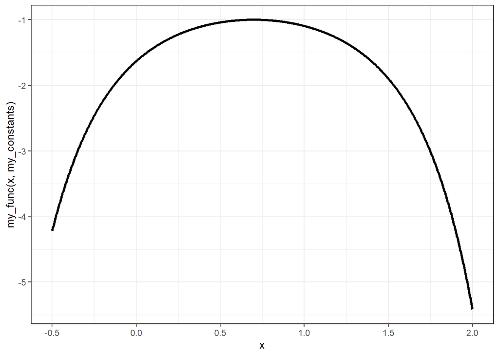

```r
tibble::tibble(
  x = seq(-0.5, 2, length.out = 1001)
) %>%
  ggplot(mapping = aes(x = x, y = my_func(x, my_constants))) +
  geom_line(linewidth = 1.15) +
  theme_bw()
```

### 4f)

We will now call `optim()` to optimize our custom function over the interval -0.5 to 2.

**Use `optim()` to find the `x` value which maximizes `my_func()`. Set the initial guess to 1.75. Set the `method` in `optim()` to be `"Brent"` and set the `hessian` argument equal to `TRUE`. Set the `lower` and `upper` arguments in the `optim()` to be -0.5 and 2, respectively. Which `control` argument in `optim()` tells `optim()` to maximize instead of minimize? We will not pass in a gradient function, what should `gr` be set to? You need to pass the `my_constants` list in order for `my_func()` to execute properly! Store the result to `opt_result` and print the result to the screen.**

#### SOLUTION

```r
opt_result <- optim(1.75,
                    my_func,
                    gr = NULL,
                    my_constants,
                    method = "Brent",
                    lower = -0.5, upper = 2,
                    hessian = TRUE,
                    control = list(fnscale = -1))

opt_result
```

```
## $par
## [1] 0.7
##
## $value
## [1] -1
##
## $counts
## function gradient
##       NA       NA
##
## $convergence
## [1] 0
##
## $message
## NULL
##
## $hessian
##           [,1]
## [1,] -2.000004
```

### 4g)

We will now plot the identified optimal `x` value as a vertical line on top of the function over the interval of interest.

**Add a vertical line with `geom_vline()` to your plot from Problem 4e). Set the `xintercept` within the `geom_vline()` function equal to the optimal `x` value by accessing the result stored in `opt_result` correctly. Set the color of the vertical line to red.**

#### SOLUTION

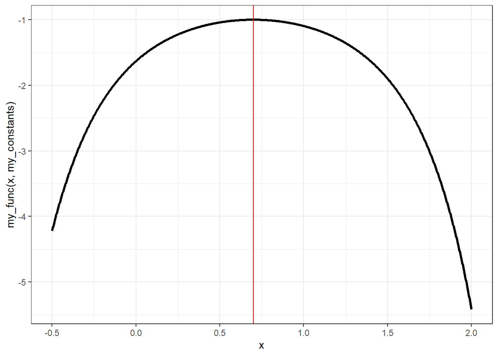

```r
tibble::tibble(
  x = seq(-0.5, 2, length.out = 1001)
) %>%
  ggplot(mapping = aes(x = x, y = my_func(x, my_constants))) +
  geom_line(linewidth = 1.15) +
  geom_vline(xintercept = opt_result$par,
             color = "red") +
  theme_bw()
```

## Problem 05

Now that you have practiced working with the `optim()` function, it’s time to use `optim()` to find the posterior mode or MAP of the unknown $\varphi$ parameter from Problem 03. Because $\varphi$ is unbounded you do not have to include the `lower` and `upper` arguments to the `optim()` function call. Otherwise the `optim()` function arguments are consistent with the previous questions from Problem 04.

### 5a)

**Use `optim()` to find the MAP of the log-transformed likelihood noise, $\varphi$, using an initial guess equal to -0.5. Assign all arguments to `optim()` that you feel are required to find the value that maximizes the log-posterior. However, assign the `method='BFGS'` instead of `method='Brent'` as used in Problem 04.**

**Assign the result to the `varphi_opt_a` object and display the object to the screen.**

**HINT**: The additional parameters to the function are supplied after `gr`. Those additional arguments should be supplied in the order consistent with the function you are optimizing.

**Continue to use `lambda = 0.75`**.

#### SOLUTION

The `log_post_varphi_unnorm()` function is optimized using the procedure stepped through in the previous problem. The `log_post_varphi_unnorm` function object is assigned as the second argument to `optim()`. The initial guess is assigned to the first argument to `optim()` and this value will be passed into `log_post_varphi_unnorm()` as its first argument. The additional arguments required to execute `log_post_varphi_unnorm()` are assigned as unnamed arguments after the `gr=NULL` argument to `optim()`. These additional arguments must be provided in the same order they appear in the `log_post_varphi_unnorm()` function.

```r
varphi_opt_a <- optim(-0.5,
                      log_post_varphi_unnorm,
                      gr = NULL,
                      N, v, 0.75,
                      method = "BFGS",
                      hessian = TRUE,
                      control = list( fnscale=-1 ))
```

The `optim()` results are displayed below. We see that it took 24 function evaluations to reach convergence and that gradient (first derivative) was evaluated 9 times. Although we will not use it in this assignment, the Hessian matrix evaluated at the mode is also printed below. With a single variable the Hessian matrix is just a scalar and corresponds to the second derivative. With this present context, since we are finding the posterior mode of the unknown log-transformed noise, $\varphi$, the second derivative is the second derivative of the (unnormalized) log-posterior with respect to $\varphi$.

```r
varphi_opt_a
```

```
## $par
## [1] 0.705349
##
## $value
## [1] -26.3846
##
## $counts
## function gradient
##       24        9
##
## $convergence
## [1] 0
##
## $message
## NULL
##
## $hessian
##          [,1]
## [1,] -44.5553
```

### 5b)

**Repeat the `optim()` call from 5a), but this time use an initial guess of 1.35. Assign the result to the `varphi_opt_b` object and display the result to the screen.**

**Is the posterior mode from the initial guess of 1.35 different from the initial guess of -0.5?**

#### SOLUTION

The optimization is repeated below but with a different starting guess than in 5a). The format is almost the same as used in the solution of Problem 5a), except that the additional arguments required to execute `log_post_varphi_unnorm()` are named. The argument names are the left side of the `=` and the value assigned to that argument is to the right of the `=`. Naming the arguments is useful if we have a large number of additional arguments to pass in. Later assignments will try to streamline this procedure by using a list as a single additional argument. The list will contain all additional pieces of information to make more streamlined for how we include more variables in the functions.

```r
varphi_opt_b <- optim(1.35,
                      log_post_varphi_unnorm,
                      gr = NULL,
                      N = N, v = v, lambda = 0.75,
                      method = "BFGS",
                      hessian = TRUE,
                      control = list( fnscale=-1 ))
```

The result is printed to the screen showing that the identified optimal value is the same as what we had previously!

```r
varphi_opt_b
```

```
## $par
## [1] 0.7053491
##
## $value
## [1] -26.3846
##
## $counts
## function gradient
##       15        6
##
## $convergence
## [1] 0
##
## $message
## NULL
##
## $hessian
##           [,1]
## [1,] -44.55529
```

The two *posterior modes* based on the different initial guess values are compared directly below.

```r
sprintf('attempt 1: %1.4f vs attempt 2: %1.4f', varphi_opt_a$par, varphi_opt_b$par)
```

```
## [1] "attempt 1: 0.7053 vs attempt 2: 0.7053"
```

The values for the mode are thus the same down to 4 decimal places. However, as we see with the `$counts` field in the `optim()` results the number of iterations are different between the two starting guesses! We should not be surprised by this result since using an initial guess further from the mode may require more steps to “climb the hill”.

### 5c)

Let’s confirm the `optim()` identified parameter value is the mode by visualizing the optimal value relative to the log-posterior of the log-transformed noise, $\varphi$.

**Visualize the un-normalized log-posterior on the transformed $\varphi$ variable, just as you did in Problem 3g). However, this time include the optimal value as a vertical red line with `geom_vline()`.**

#### SOLUTION

As we can see below the value identified by `optim()` does indeed correspond to the maximum log-posterior density! It does not matter which `optim()` result we use for this figure because the results are the same.

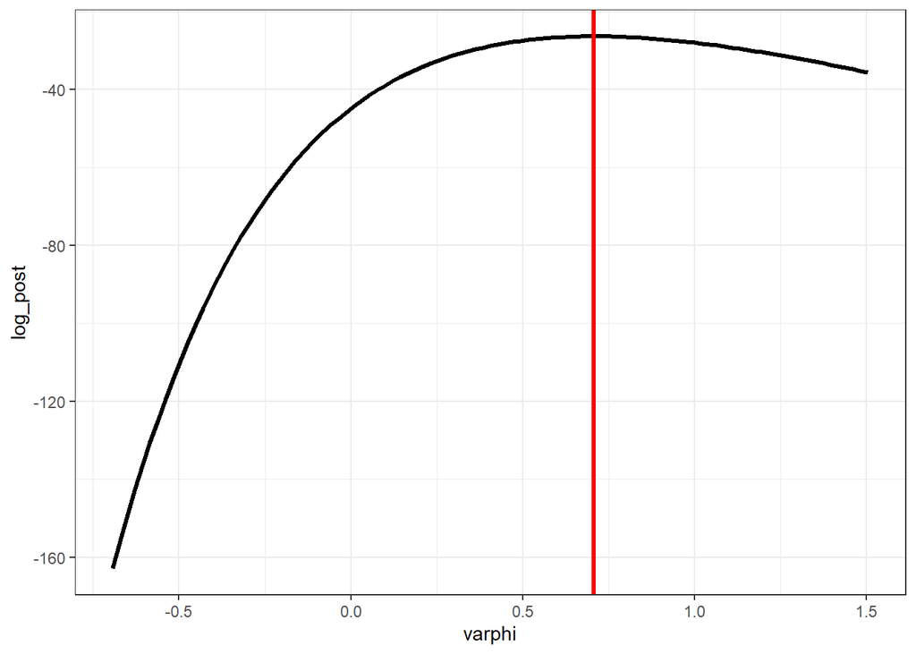

```r
tibble::tibble(
  varphi = seq(log(0.5), log(4.5), length.out = 101)
) %>%
  mutate(log_post = log_post_varphi_unnorm(varphi, N = N, v = v, lambda = 0.75)) %>%
  ggplot(mapping = aes(x = varphi, y = log_post)) +
  geom_line(linewidth = 1.15) +
  geom_vline(xintercept = varphi_opt_a$par,
             color = 'red', linewidth = 1.2) +
  theme_bw()
```